# Analysis

Florian Hartig

7/20/2017

```r
load(file = "../data/cleaned.RData")

library(lme4)
library(lmerTest)
library(vegan)
library(betapart)
```

Notes: habitats are occasionally abbreviate with German words MR (Magerrasen) = dry grassland, FW (Fettwiese) = Hay Meadow.

# Alpha diversity comparison

## Taxonomic alpha

First of all, we see a clear habitat pattern (Fig. 2 in main paper)

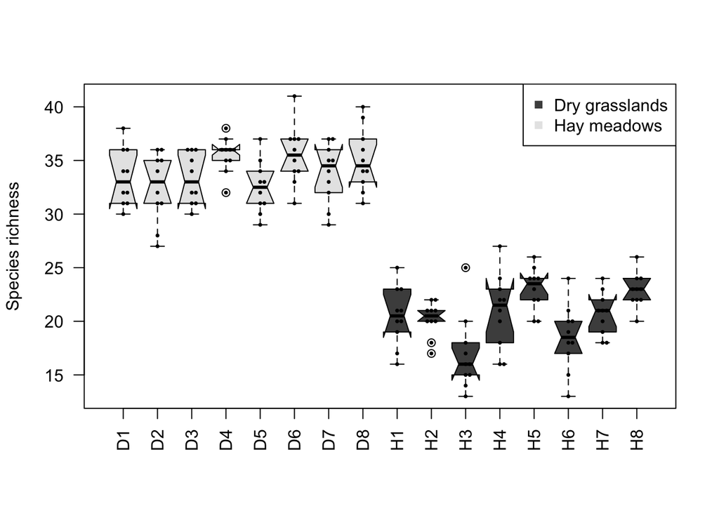

```r
plot(alpha ~ as.factor(Plot) , data = sites$alpha2, ylab = "Species richness", xlab = "", col = grey.colors(2)[as.numeric(Habitat)], las = 2, notch = T)
legend("topright", c("Dry grasslands", "Hay meadows"), pch = 15, col = grey.colors(2))

library(beeswarm)
beeswarm(alpha ~ as.factor(Plot) , data = sites$alpha2, add = T, cex = 0.5, pch = 16)
```

Regression to test for the dependence of alpha on all predictors

```r
alphaT = glmer(alpha ~ Habitat + scale(Distanz) + scale(`HA (m²)`) +  (1|Plot), data = sites$alpha2, family = poisson)
```

```
## boundary (singular) fit: see ?isSingular
```

```r
summary(alphaT)
```

```
## Generalized linear mixed model fit by maximum likelihood (Laplace
##   Approximation) [glmerMod]
##  Family: poisson  ( log )
## Formula: alpha ~ Habitat + scale(Distanz) + scale(`HA (m²)`) + (1 | Plot)
##    Data: sites$alpha2
##
##      AIC      BIC   logLik deviance df.resid
##    883.6    899.0   -436.8    873.6      155
##
## Scaled residuals:
##      Min       1Q   Median       3Q      Max
## -1.58893 -0.39694  0.08864  0.37352  1.53683
##
## Random effects:
##  Groups Name        Variance Std.Dev.
##  Plot   (Intercept) 0        0
## Number of obs: 160, groups:  Plot, 16
##
## Fixed effects:
##                    Estimate Std. Error z value Pr(>|z|)
## (Intercept)        3.024937   0.027301 110.800   <2e-16 ***
## HabitatMagerrasen  0.492702   0.039113  12.597   <2e-16 ***
## scale(Distanz)     0.018518   0.017535   1.056    0.291
## scale(`HA (m²)`)  -0.003164   0.015641  -0.202    0.840
## ---
## Signif. codes:  0 '***' 0.001 '**' 0.01 '*' 0.05 '.' 0.1 ' ' 1
```

```
##
## Correlation of Fixed Effects:
```

```
##             (Intr) HbttMg scl(D)
## HabttMgrrsn -0.827
## scal(Dstnz)  0.340 -0.487
## sc(`HA(²)`)  0.319 -0.444  0.207
## convergence code: 0
## boundary (singular) fit: see ?isSingular
```

Further plots to explore possible nonlinear confounding with other predictors

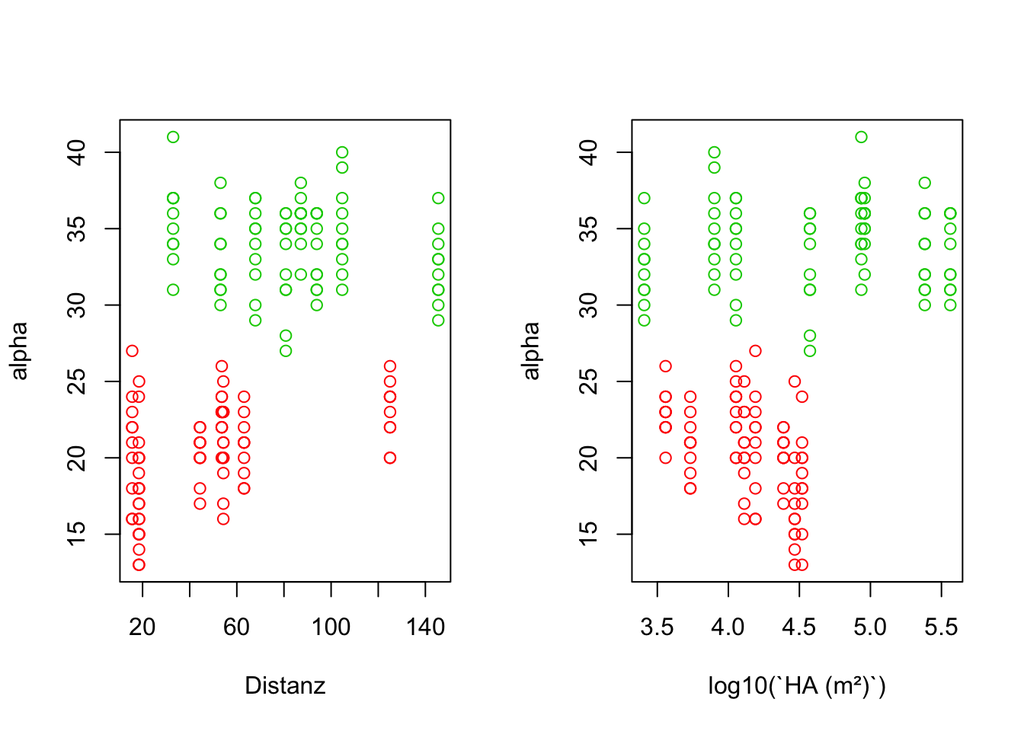

```r
par(mfrow = c(1,2))
plot(alpha ~ Distanz , data = sites$alpha2, col = as.numeric(Habitat)+1)
plot(alpha ~ log10(`HA (m²)`) , data = sites$alpha2, col = as.numeric(Habitat)+1)
```

Conclusion is that taxonomic diversity that the only significant factor associated with taxonomic alpha is habitat (Magerrasen has higher tax alpha).

## Genetic alpha

Genetic alpha diversity (measured in SSWP/n-1) for the 6 species each in the dry and mesic grasslands against the frequency (FR) of subplots in which the species was found. The dashed line in each plot shows a linear regression estimate across all species in a given habitat, the solid lines show linear regression estimate per species.

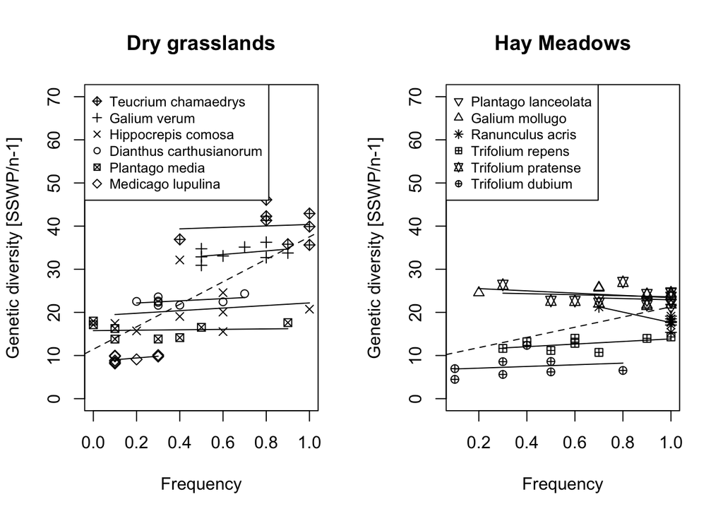

```r
par(mfrow = c(1,2))
plot(`SSWP/n-1` ~ FR , data = sites$genAlpha[sites$genAlpha$Habitat == "Magerrasen",], main = "Dry grasslands", pch = as.numeric(Art), xlab = "Frequency", ylab = "Genetic diversity [SSWP/n-1]", ylim = c(0,70) )

fit <- lm(`SSWP/n-1` ~ FR , data = sites$genAlpha[sites$genAlpha$Habitat == "Magerrasen",])
abline(fit, lty = 2)

species = unique(sites$genAlpha$Art[sites$genAlpha$Habitat == "Magerrasen"])
for(sp in species){
  xrange = range(sites$genAlpha$FR[sites$genAlpha$Art == sp])
  fit <- lm(`SSWP/n-1` ~ FR , data = sites$genAlpha[sites$genAlpha$Art == sp,])
  y1 = predict(fit, newdata = data.frame(FR = xrange[1]))
  y2 = predict(fit, newdata = data.frame(FR = xrange[2]))
  lines(xrange, c(y1, y2))
}

legend("topleft", legend = species, pch=as.numeric(species), cex = 0.8 )


plot(`SSWP/n-1` ~ FR , data = sites$genAlpha[sites$genAlpha$Habitat == "Fettwiese",], main = "Hay Meadows", pch = as.numeric(Art), xlab = "Frequency", ylab = "Genetic diversity [SSWP/n-1]", ylim = c(0,70))


fit <- lm(`SSWP/n-1` ~ FR , data = sites$genAlpha[sites$genAlpha$Habitat == "Fettwiese",])
abline(fit, lty = 2)

species = unique(sites$genAlpha$Art[sites$genAlpha$Habitat == "Fettwiese"])
for(sp in species){
  xrange = range(sites$genAlpha$FR[sites$genAlpha$Art == sp])
  fit <- lm(`SSWP/n-1` ~ FR , data = sites$genAlpha[sites$genAlpha$Art == sp,])
  y1 = predict(fit, newdata = data.frame(FR = xrange[1]))
  y2 = predict(fit, newdata = data.frame(FR = xrange[2]))
  lines(xrange, c(y1, y2))
}

legend("topleft", legend = species, pch=as.numeric(species), cex = 0.8 )
```

The comparison suggests that genetic diversity differs little within species, and apparent correlations between FR and genetic diversity occur because of a confounding of FR with species. To seperate these effects, we calculated linear mixed models, with population and species as random intercepts.

```r
full <- lmer(`SSWP/n-1` ~  Habitat * scale(FR) + scale(`HA (m²)`) + scale(Distanz) + (1|Population) + (1|Art) ,  data = sites$genAlpha, REML = F)
summary(full)
```

```
## Linear mixed model fit by maximum likelihood . t-tests use
##   Satterthwaite's method [lmerModLmerTest]
## Formula:
## `SSWP/n-1` ~ Habitat * scale(FR) + scale(`HA (m²)`) + scale(Distanz) +
##     (1 | Population) + (1 | Art)
##    Data: sites$genAlpha
##
##      AIC      BIC   logLik deviance df.resid
##    511.2    534.3   -246.6    493.2       87
##
## Scaled residuals:
##     Min      1Q  Median      3Q     Max
## -2.3640 -0.5007 -0.0612  0.4707  4.6340
##
## Random effects:
##  Groups     Name        Variance Std.Dev.
##  Population (Intercept)  0.2302  0.4798
##  Art        (Intercept) 66.9680  8.1834
##  Residual                5.4261  2.3294
## Number of obs: 96, groups:  Population, 16; Art, 12
##
## Fixed effects:
##                             Estimate Std. Error      df t value Pr(>|t|)
## (Intercept)                  18.4747     3.3823 12.0918   5.462 0.000141
## HabitatMagerrasen             5.4216     4.7906 12.1681   1.132 0.279569
## scale(FR)                    -0.1911     0.5982 85.4007  -0.319 0.750224
## scale(`HA (m²)`)              0.2236     0.3066 13.2769   0.729 0.478428
## scale(Distanz)                0.2373     0.3246 15.7950   0.731 0.475424
## HabitatMagerrasen:scale(FR)   1.1369     0.8206 83.1458   1.386 0.169593
##
## (Intercept)                 ***
## HabitatMagerrasen
## scale(FR)
## scale(`HA (m²)`)
## scale(Distanz)
## HabitatMagerrasen:scale(FR)
## ---
## Signif. codes:  0 '***' 0.001 '**' 0.01 '*' 0.05 '.' 0.1 ' ' 1
```

```
##
## Correlation of Fixed Effects:
```

```
##             (Intr) HbttMg sc(FR) s(`HA( scl(D)
## HabttMgrrsn -0.710
## scale(FR)   -0.089  0.072
## sc(`HA(²)`)  0.054 -0.073 -0.053
## scal(Dstnz)  0.075 -0.085 -0.304  0.200
## HbttMg:(FR)  0.069 -0.027 -0.750  0.042  0.291
```

Which showed that none of the factors are significant. Habitat is also not significant in a single regression, as long as species identity is included as a random intercept.

```r
full <- lmer(`SSWP/n-1` ~ Habitat + (1|Population) + (1|Art),  data = sites$genAlpha, REML = F)
summary(full)
```

```
## Linear mixed model fit by maximum likelihood . t-tests use
##   Satterthwaite's method [lmerModLmerTest]
## Formula: `SSWP/n-1` ~ Habitat + (1 | Population) + (1 | Art)
##    Data: sites$genAlpha
##
##      AIC      BIC   logLik deviance df.resid
##    506.8    519.6   -248.4    496.8       91
##
## Scaled residuals:
##     Min      1Q  Median      3Q     Max
## -2.1299 -0.5121 -0.0549  0.4621  4.7175
##
## Random effects:
##  Groups     Name        Variance Std.Dev.
##  Population (Intercept)  0.1304  0.3612
##  Art        (Intercept) 72.8985  8.5381
##  Residual                5.6877  2.3849
## Number of obs: 96, groups:  Population, 16; Art, 12
##
## Fixed effects:
##                   Estimate Std. Error     df t value Pr(>|t|)
## (Intercept)         18.186      3.505 12.030   5.189 0.000224 ***
## HabitatMagerrasen    5.530      4.957 12.030   1.116 0.286378
## ---
## Signif. codes:  0 '***' 0.001 '**' 0.01 '*' 0.05 '.' 0.1 ' ' 1
##
## Correlation of Fixed Effects:
##             (Intr)
## HabttMgrrsn -0.707
```

However, species is obviously a signficant predictor for both genetic diversity. The problem is that species is perfectly collinear with habitat, and closely colinear with FR, so that it’s difficult to separate these effects.

```r
fit <- lmer(`SSWP/n-1` ~  Art + (1|Population)  ,  data = sites$genAlpha)
anova(fit)
```

```
## Type III Analysis of Variance Table with Satterthwaite's method
##     Sum Sq Mean Sq NumDF  DenDF F value    Pr(>F)
## Art 7709.1  700.82    11 75.813  123.25 < 2.2e-16 ***
## ---
## Signif. codes:  0 '***' 0.001 '**' 0.01 '*' 0.05 '.' 0.1 ' ' 1
```

Both habitat and frequency would be siginficant when not controlling for species identity, but given the previous results, and the apparent collinearity between species identity and other factors, this seems statistically not sensible.

```r
full <- lmer(`SSWP/n-1` ~  Habitat * scale(FR) + scale(`HA (m²)`) + scale(Distanz) + (1|Population)  ,  data = sites$genAlpha, REML = F)
```

```
## boundary (singular) fit: see ?isSingular
```

```r
summary(full)
```

```
## Linear mixed model fit by maximum likelihood . t-tests use
##   Satterthwaite's method [lmerModLmerTest]
## Formula:
## `SSWP/n-1` ~ Habitat * scale(FR) + scale(`HA (m²)`) + scale(Distanz) +
##     (1 | Population)
##    Data: sites$genAlpha
##
##      AIC      BIC   logLik deviance df.resid
##    647.2    667.7   -315.6    631.2       88
##
## Scaled residuals:
##      Min       1Q   Median       3Q      Max
## -2.66122 -0.70808  0.02347  0.63996  2.32656
##
## Random effects:
##  Groups     Name        Variance Std.Dev.
##  Population (Intercept)  0.00    0.00
##  Residual               41.99    6.48
## Number of obs: 96, groups:  Population, 16
##
## Fixed effects:
##                              Estimate Std. Error        df t value
## (Intercept)                 16.669891   1.212008 96.000000  13.754
## HabitatMagerrasen           10.461055   1.855476 96.000000   5.638
## scale(FR)                    3.816992   1.103762 96.000000   3.458
## scale(`HA (m²)`)             0.130509   0.761002 96.000000   0.171
## scale(Distanz)               0.004005   0.787422 96.000000   0.005
## HabitatMagerrasen:scale(FR)  4.598303   1.502450 96.000000   3.061
##                             Pr(>|t|)
## (Intercept)                  < 2e-16 ***
## HabitatMagerrasen           1.73e-07 ***
## scale(FR)                   0.000812 ***
## scale(`HA (m²)`)            0.864195
## scale(Distanz)              0.995952
## HabitatMagerrasen:scale(FR) 0.002865 **
## ---
## Signif. codes:  0 '***' 0.001 '**' 0.01 '*' 0.05 '.' 0.1 ' ' 1
```

```
##
## Correlation of Fixed Effects:
```

```
##             (Intr) HbttMg sc(FR) s(`HA( scl(D)
## HabttMgrrsn -0.799
## scale(FR)   -0.456  0.346
## sc(`HA(²)`)  0.357 -0.456 -0.039
## scal(Dstnz)  0.441 -0.503 -0.230  0.197
## HbttMg:(FR)  0.355 -0.130 -0.746  0.031  0.220
## convergence code: 0
## boundary (singular) fit: see ?isSingular
```

In fact, it seems that both the habitat effects and the frequency effects in the latter regression are essentially driven by species identity, in that some species simply have a higher diversity, or at least there are not enough species to separate between an effect of species identity, and true FR / Habitat effects.

To confirm that intutition, we additinally calculated a t-test between the average genetic diversity values per species for each habitat (n=6 for each group)

```r
x = aggregate(`SSWP/n-1` ~ Art + Habitat, FUN = mean, data = sites$genAlpha)
t.test(`SSWP/n-1` ~ Habitat, data = x)
```

```
##
##  Welch Two Sample t-test
##
## data:  SSWP/n-1 by Habitat
## t = -1.0192, df = 8.2069, p-value = 0.3372
## alternative hypothesis: true difference in means is not equal to 0
## 95 percent confidence interval:
##  -17.986717   6.927195
## sample estimates:
##  mean in group Fettwiese mean in group Magerrasen
##                 18.18584                 23.71560
```

Which is n.s.

The correlation between species

```r
x1 = aggregate(`SSWP/n-1` ~ Art, FUN = mean, data = sites$genAlpha)
x2 = aggregate(FR ~ Art, FUN = mean, data = sites$genAlpha)
cor.test(x1$`SSWP/n-1`, x2$FR)
```

```
##
##  Pearson's product-moment correlation
##
## data:  x1$`SSWP/n-1` and x2$FR
## t = 2.1086, df = 10, p-value = 0.06119
## alternative hypothesis: true correlation is not equal to 0
## 95 percent confidence interval:
##  -0.02807041  0.85610208
## sample estimates:
##       cor
## 0.5547683
```

# Beta diversity comparison

## Taxonomic beta

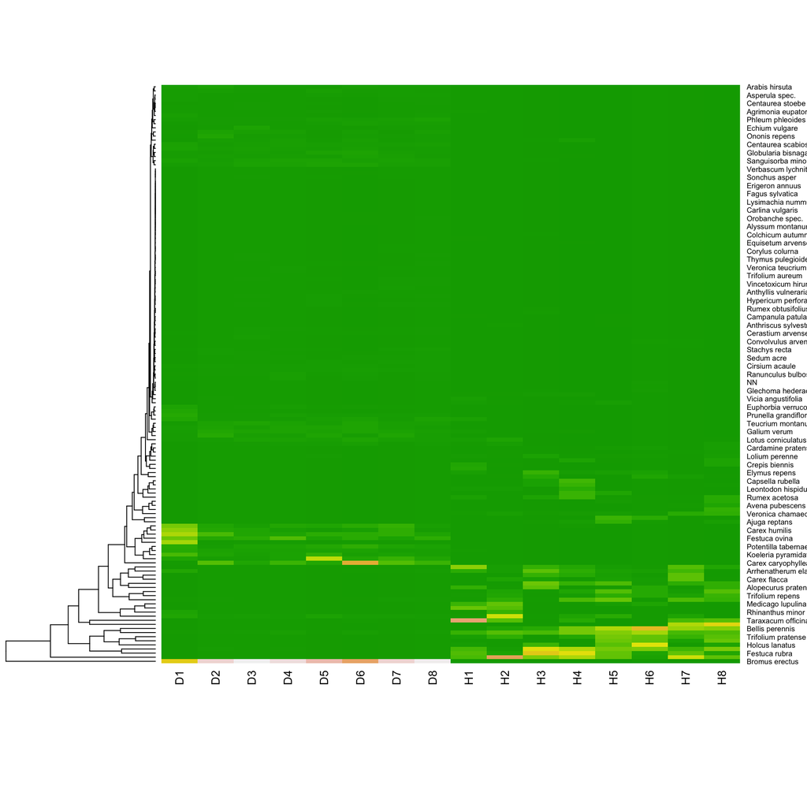

```r
heatmap(t(sites$community), Colv = NA,scale="column", col = terrain.colors(256))
```

```r
distSpecies = vegdist(sites$community, method="bray")

mod <- betadisper(distSpecies, sites$alpha$Habitat)
mod
```

```
##
##  Homogeneity of multivariate dispersions
##
## Call: betadisper(d = distSpecies, group = sites$alpha$Habitat)
##
## No. of Positive Eigenvalues: 15
## No. of Negative Eigenvalues: 0
##
## Average distance to median:
##  Fettwiese Magerrasen
##     0.3756     0.2435
##
## Eigenvalues for PCoA axes:
## (Showing 8 of 15 eigenvalues)
##   PCoA1   PCoA2   PCoA3   PCoA4   PCoA5   PCoA6   PCoA7   PCoA8
## 3.04065 0.40635 0.31489 0.23082 0.20848 0.14773 0.12665 0.07148
```

```r
anova(mod)
```

```
## Analysis of Variance Table
##
## Response: Distances
##           Df   Sum Sq  Mean Sq F value  Pr(>F)
## Groups     1 0.069824 0.069824   5.515 0.03407 *
## Residuals 14 0.177250 0.012661
## ---
## Signif. codes:  0 '***' 0.001 '**' 0.01 '*' 0.05 '.' 0.1 ' ' 1
```

```r
permutest(mod, pairwise = TRUE, permutations = 499)
```

```
##
## Permutation test for homogeneity of multivariate dispersions
## Permutation: free
## Number of permutations: 499
##
## Response: Distances
##           Df   Sum Sq  Mean Sq     F N.Perm Pr(>F)
## Groups     1 0.069824 0.069824 5.515    499  0.042 *
## Residuals 14 0.177250 0.012661
## ---
## Signif. codes:  0 '***' 0.001 '**' 0.01 '*' 0.05 '.' 0.1 ' ' 1
##
## Pairwise comparisons:
## (Observed p-value below diagonal, permuted p-value above diagonal)
##            Fettwiese Magerrasen
## Fettwiese                 0.038
## Magerrasen  0.034066
```

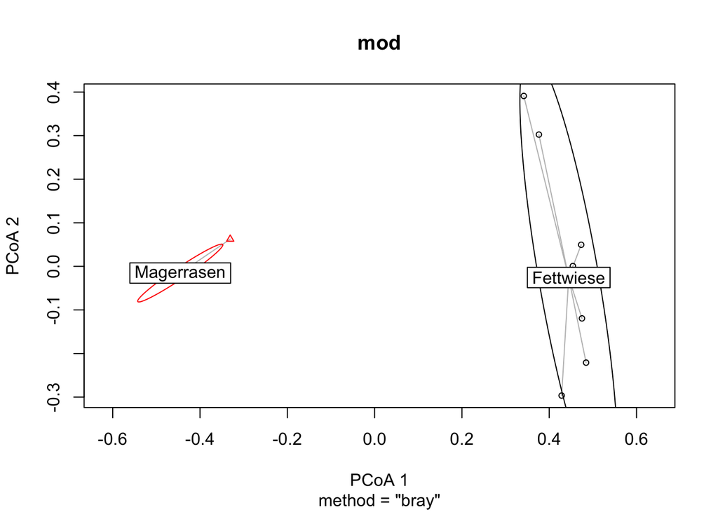

```r
plot(mod, ellipse = TRUE, hull = FALSE, conf = 0.90) # 90% data ellipse
```

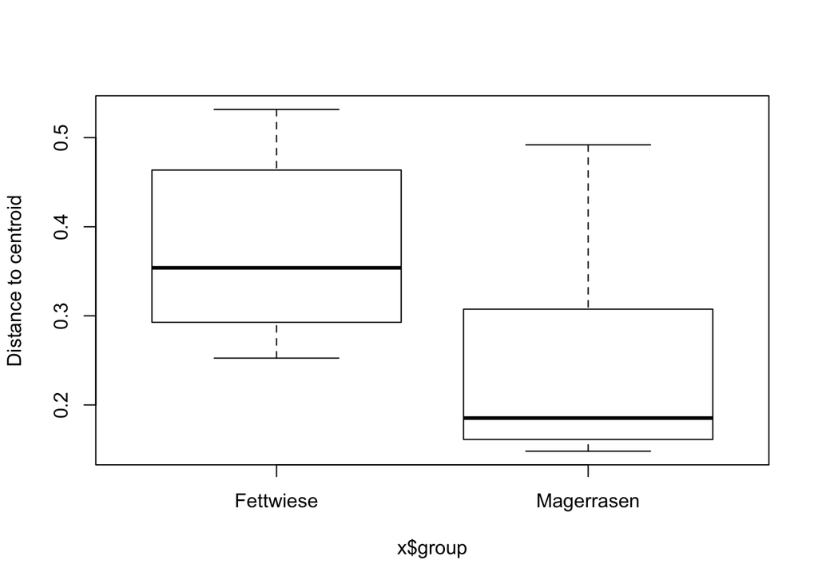

```r
boxplot(mod)
```

Mantel test for spatial structure

```r
mantel(as.matrix(distSpecies)[1:8,1:8], sites$geoDist[1:8,1:8], method="pearson", permutations=999)
```

```
##
## Mantel statistic based on Pearson's product-moment correlation
##
## Call:
## mantel(xdis = as.matrix(distSpecies)[1:8, 1:8], ydis = sites$geoDist[1:8,      1:8], method = "pearson", permutations = 999)
##
## Mantel statistic r: 0.3382
##       Significance: 0.109
##
## Upper quantiles of permutations (null model):
##   90%   95% 97.5%   99%
## 0.353 0.428 0.478 0.537
## Permutation: free
## Number of permutations: 999
```

```r
mantel(as.matrix(distSpecies)[9:16,9:16], sites$geoDist[9:16,9:16], method="pearson", permutations=999)
```

```
##
## Mantel statistic based on Pearson's product-moment correlation
##
## Call:
## mantel(xdis = as.matrix(distSpecies)[9:16, 9:16], ydis = sites$geoDist[9:16,      9:16], method = "pearson", permutations = 999)
##
## Mantel statistic r: 0.5542
##       Significance: 0.003
##
## Upper quantiles of permutations (null model):
##   90%   95% 97.5%   99%
## 0.239 0.333 0.421 0.457
## Permutation: free
## Number of permutations: 999
```

Result: FW not significant with geographic distance, but MR is probably (stronger driven by environment)

## Genetic Beta

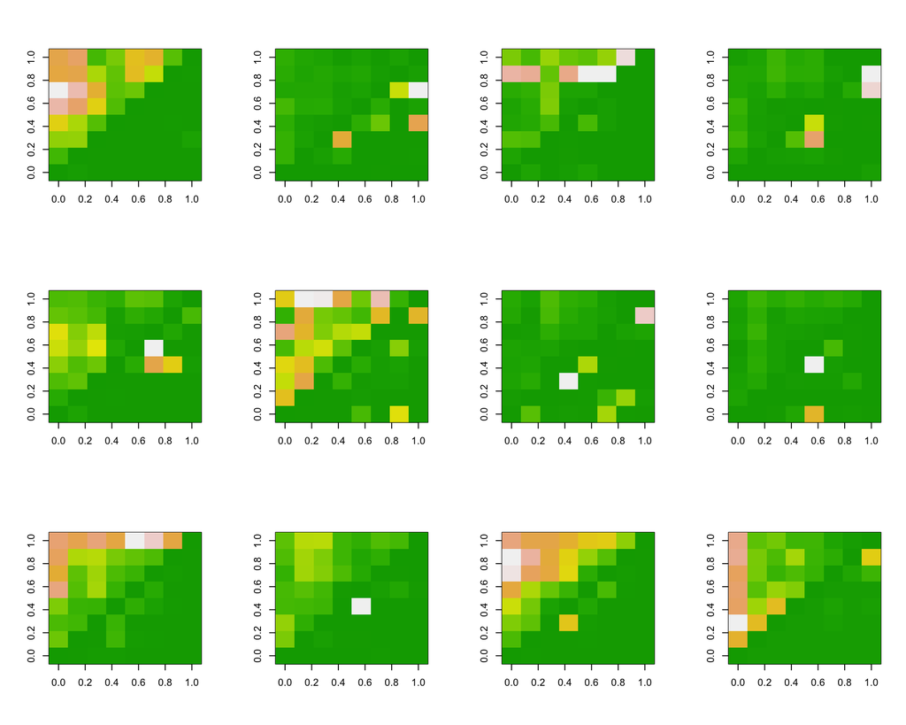

```r
par(mfrow = c(3,4))
for(i in 1:12) image(t(sites$genBeta[[i]]), col = terrain.colors(256))
```

Regression PhiPT gegen Habitat

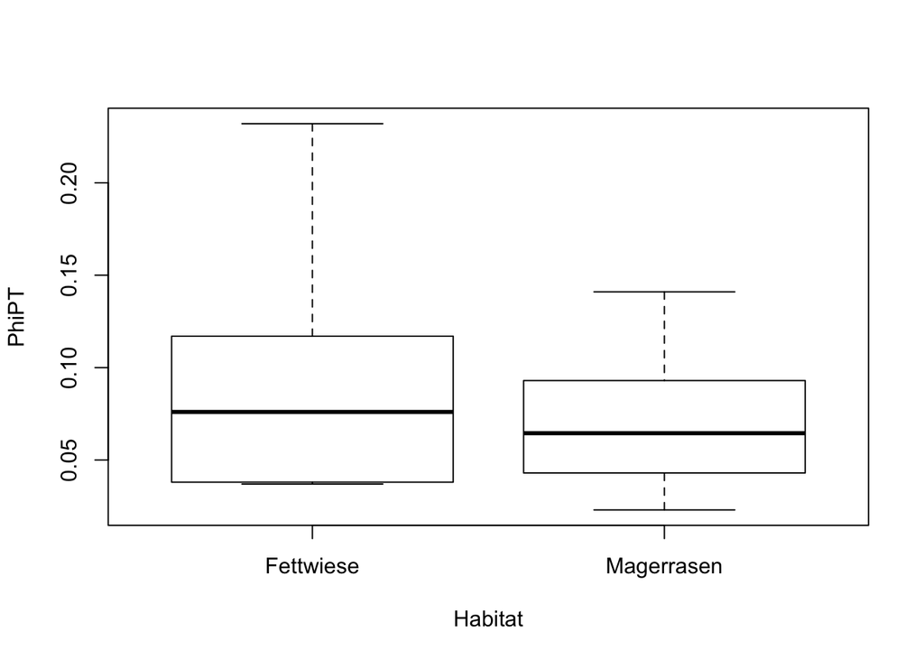

```r
boxplot(PhiPT ~  Habitat ,  data = sites$genAlpha[1:12])
```

```r
fit <- lm(PhiPT ~  Habitat ,  data = sites$genAlpha[c(1:6, 49:54),])
summary(fit)
```

```
##
## Call:
## lm(formula = PhiPT ~ Habitat, data = sites$genAlpha[c(1:6, 49:54),
##     ])
##
## Residuals:
##      Min       1Q   Median       3Q      Max
## -0.05900 -0.03350 -0.01475  0.02113  0.13600
##
## Coefficients:
##                   Estimate Std. Error t value Pr(>|t|)
## (Intercept)        0.09600    0.02426   3.958   0.0027 **
## HabitatMagerrasen -0.02450    0.03430  -0.714   0.4914
## ---
## Signif. codes:  0 '***' 0.001 '**' 0.01 '*' 0.05 '.' 0.1 ' ' 1
##
## Residual standard error: 0.05941 on 10 degrees of freedom
## Multiple R-squared:  0.04854,    Adjusted R-squared:  -0.04661
## F-statistic: 0.5101 on 1 and 10 DF,  p-value: 0.4914
```

```r
t.test(sites$genAlpha$PhiPT[1:6], sites$genAlpha$PhiPT[49:54])
```

```
##
##  Welch Two Sample t-test
##
## data:  sites$genAlpha$PhiPT[1:6] and sites$genAlpha$PhiPT[49:54]
## t = -0.71424, df = 7.9428, p-value = 0.4955
## alternative hypothesis: true difference in means is not equal to 0
## 95 percent confidence interval:
##  -0.10370052  0.05470052
## sample estimates:
## mean of x mean of y
##    0.0715    0.0960
```

Mantel tests to test for spatial signal in genetic diversity

```r
# note: genetic data are ordered first the MR species, then the FW
distSpecies = vegdist(sites$community, method="bray")

outMR = rep(NA,6)
for (i in 7:12) outMR[i-6] = mantel(sites$genBeta[[i]], sites$geoDist[1:8,1:8])$signif
outMR
```

```
## [1] 0.140 0.178 0.028 0.020 0.001 0.038
```

```r
outFW = rep(NA,6)
for (i in 1:6) outFW[i] = mantel(sites$genBeta[[i]], sites$geoDist[9:16,9:16])$signif
outFW
```

```
## [1] 0.005 0.023 0.462 0.098 0.027 0.092
```

# Taxonomic Gamma

```r
countsFW = apply(sites$community[1:8,],2, sum)
countsMR = apply(sites$community[9:16,],2, sum)
sum(countsFW > 0)
```

```
## [1] 92
```

```r
sum(countsMR > 0)
```

```
## [1] 70
```

Result: FW has higher diversity